# Getting Started With care4cmodel

This vignette’s purpose is to serve as a guide for getting quickly started with the R package *care4cmodel*. While we give a short introduction the concept of the package below, we assume that you already know why you want to use the package, and that you are not completely unfamiliar with the idea behind it. Here, we will only provide scientific details if they are necessary for understanding how to work with the package. For a complete and detailed scientific presentation see [Biber et al. (2024)](https://doi.org/10.1016/j.compag.2024.109091).

## 1 Concept of the package

The R package *care4cmodel* has been designed in the context of quantifying carbon flows related to the growth and management of forests. It is, in essence, a dynamic simulation model that is surrounded with tools to enable users to quickly set up and simulate scenarios and evaluate them. The current version is made for evaluating silvicultural concepts with a focus on opposing the CO<sub>2</sub> uptake from wood growth to the CO<sub>2</sub> emissions caused by forest operations.

The basic idea of the model is that a forest area managed under a given concept can be adequately represented by a set of forest development stages, each of which covers a certain share of the total area. These area shares change dynamically over time due to continuous forest dynamics, but they can also change abruptly due to hazard events. Any further simulation results are basically obtained by upscaling phase-wise information to these areas. Note, that *care4cmodel* is not a growth and yield simulator in the usual sense, i.e. the required basic growth and yield information relating to the concept of interest must be provided by the user (see Section 3.1). While the current implementation is constrained to providing the carbon related information as mentioned above, the concept of the model is generic and lends itself to a broad variety of applications.

## 2 Quickstart

If you simply want to run and evaluate a simulation without further reading, here’s your code:

```r
library(care4cmodel) # Attach the package

# Run a simulation and store its base results in a variable sim_base_out
# call ?simulate_single_concept for details
sim_base_out <- simulate_single_concept(
    concept_def = pine_thinning_from_above_1, # use pre-defined concept
    init_areas  = c(800, 0, 0, 0, 0, 200),
    time_span   = 200,
    risk_level  = 3
)

# Evaluate the base results for carbon related information
# call ?fuel_and_co2_evaluation for details
carbon_out <- fuel_and_co2_evaluation(sim_base_out, road_density_m_ha = 35)
```

Both result variables, `sim_base_out`, and `carbon_out` contain large objects which are, in essence, named lists. You can easily explore them manually, but there exist convenient functions for visualization:

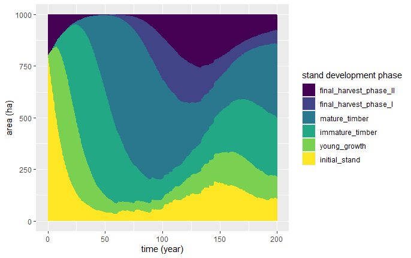

```r
# Plot base results. Without further specifications, this will generate a plot
# of the areas covered by the stand development phases over time

# Check the documentation with ?plot.c4c_base_result in order to see all
# options for plotting, especially growth and yield variables
plot(sim_base_out)
```

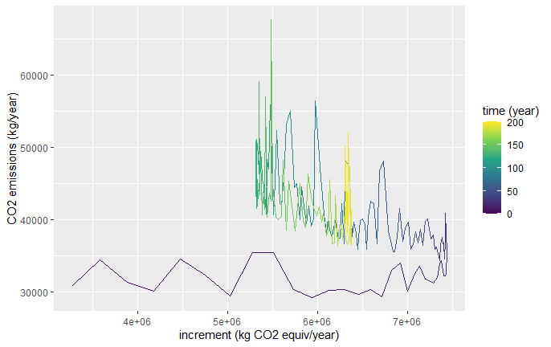

```r
# Plot carbon related results. The selected option for plot_type generates a
# phase diagram where the total CO2 emissions due to forest operations are
# plotted over the CO2 sequestered by wood growth.

# Check the documentation with ?plot.c4c_co2_result in order to see all options
# for plotting
plot(carbon_out, plot_type = "em_vs_inc")
```

Great, if this got you sufficiently started. If you want more explanations, read on.

## 3 Using care4cmodel

After installing the package on your computer, the easiest (and standard) way to access the functionality of the package is to attach it with

```r
library(care4cmodel)
```

### 3.1 Silvicultural concept definition

The fundamental requirement for running simulations with *care4cmodel* is an appropriate definition of the silvicultural concept of interest. Such definitions are objects of class *c4c_concept*, and the most convienent way to generate one of your own is to use the function `c4c_concept()`. The main argument to that function is a data frame with growth and yield information, as defined below. Many users will find it convenient to assemble this information in a spreadsheet software like MS EXCEL, and import it into R as a data frame. With `?c4c_concept` you can call the documentation of `c4c_concept()`. Using this function includes a series of automatic checks in order to ensure that the definition is technically correct. The package contains two pre-defined concept definitions, `pine_thinning_from_above_1`, and, `pine_no_thinning_and_clearcut_1`. We use the former for explaining the main content of such a definition. Simply type the name of the concept to display its contents:

```r
pine_thinning_from_above_1
```

```
#> $concept_name
#> [1] "Scots pine thinning from above"
#>
#> $units
#>          time          area        volume          mass stem_diameter
#>        "year"          "ha"          "m3"           "t"          "cm"
#>
#> $growth_and_yield
#> # A tibble: 6 × 14
#>   phase_no phase_name      duration n_subphases vol_standing vol_remove vol_mort
#>      <int> <chr>              <dbl>       <dbl>        <dbl>      <dbl>    <dbl>
#> 1        1 initial_stand         15           3          0         0       0
#> 2        2 young_growth          14           3         58.5       0       0.142
#> 3        3 immature_timber       29           6        206.        1.64    1.72
#> 4        4 mature_timber         49          10        374.        4.38    1.60
#> 5        5 final_harvest_…       19           4        446.        8.78    0.584
#> 6        6 final_harvest_…       29           6        378.       16.5     0.471
#> # ℹ 7 more variables: n_standing <dbl>, n_remove <dbl>, dbh_standing <dbl>,
#> #   dbh_remove <dbl>, harvest_interval <dbl>, survival_cum <dbl>,
#> #   vol_increment <dbl>
#>
#> attr(,"class")
#> [1] "c4c_concept"
```

Basically, such an object of class `c4c_concept` (as created with the function of the same name) is a list with three elements. The first element, `concept_name` is to be defined by the user. The second element, `units` lists the most important units to be used when simulating this concept. This feature is not actively used in the current version (and is not required to be defined by the user), i.e. all numbers connected to any silvicultural concept are understood in these units if not explicitly stated otherwise. However in future versions, it is planned to be more flexible in that regard. The third element, `growth_and_yield` is actually the most important. It is a data frame that defines the stand development phases to be considered, their duration, and a set of fundamental growth and yield variables. Typically this information comes from observational plots, silvicultural guidelines, forest growth simulators, yield tables, and similar sources, or a mixture of these.

The number of stand development phases is totally up to the user; for most applications, however, four to seven phases should be sufficient. Each line of the data frame completely defines one such phase. The phases are taken to be subsequent to each other in the order of the column `phase_no`. The last phase is followed by the first phase again, which typically means a final harvest followed by an initial stand. The columns of the data frame are defined as follows (note that, depending on your system, the contents of some columns, and some columns themselves might be cut off in the display above):

- **phase_no** Integer numbers that indicate the sequence of how the stand development phases follow after each other
- **phase_name** User-defined names for the stand development phases, must be unique
- **duration** The (average) duration of each phase in years
- **n_subphases** Integer numbers >= 1, indicating the number of subphases to each phase to be considered internally. This is useful and required for adjusting the “blur” when forest areas move through a sequence of phases. I.e. when a stand development phase has a duration of $D$ years, and $n$ subphases, a unit area will remain on average $D$ years in that phase, but with a variance of $\sigma^2=\frac{D^2}{n}$. In many cases, the rule of thumb to have at least three subphases and otherwise $\frac{D}{n}\approx 5$, will be adequate.
- **vol_standing** The average standing wood volume (m³/ha) of a stand in the phase of interest
- **vol_remove** The wood volume (m³/ha/a) that is regularly removed (harvested) per year and hectare from a stand in the phase of interest. This does not include wood that is harvested due (partial) stand destruction by hazard events
- **vol_mort** The wood volume (m³/ha/a) that is regularly dying per year and hectare in the phase of interest. Like vol_remove, this does not include mortality due to stand destruction by hazard events
- **n_standing** The average number of standing live trees per hectare in a stand of the given phase
- **n_remove** The number of trees that are removed per hectare and year due to regular harvest in the phase of interest
- **dbh_standing** The average mean diameter at breast height, dbh (cm), of a stand in the phase of interest
- **dbh_remove** The average mean dbh (cm) of the trees being regularly harvested in a stand of the given phase
- **harvest_interval** While vol_remove, and n_remove are annual numbers, the harvest interval is the actual time between two harvest operations in the phase of interest
- **survival_cum** Probability (i.e. number between 0 and 1) of a stand to survive all occuring hazard events *since the beginning of the first phase* to the end of the phase of interest. Therefore, the sequence of these numbers must be decreasing along the sequence of phases. The sequence of probabilities given in the concept definition is considered the baseline risk. We demonstrate below how that baseline can be conveniently adjusted for covering other risk scenarios
- **vol_increment** The average annual wood volume incrment (m³/ha/a) in the phase of interest. Unlike the previous variables, vol_increment is not required to be provided by the user when generating a concept definition with `c4c_concept()`. It results directly from the phase durations, the standing volumes, the removal, and the mortality volume

### 3.2 Running a simulation

The workhorse function for conducting simulation runs with *care4cmodel* is `simulate_single_concept()`. For simulating an example with the concept `pine_thinning_from_above_1` we use it as follows:

```r
sim_base_out <- simulate_single_concept(
    concept_def = pine_thinning_from_above_1,
    init_areas  = c(1000, 0, 0, 0, 0, 0),
    time_span   = 200,
    risk_level  = 3
)
```

The first argument `concept_def` is the definition of the silvicultural concept to be used, it must be a valid object of class `c4c_concept` (Section 3.1). The second argument, `init_areas`, is a vector that sets the initial areas covered by the stand development phases as defined in the silvicultural concept (in ascending order). In the example, `init_areas` indicates 1000 ha in the first stand development phase, and no areas covered by any other phase. This can be seen as an afforestation of a 1000 ha forest area. During the simulation, the total area (1000 ha in our example) will remain constant, while the shares of the phases will be changing. The size of the areas and their initial distribution is fully up to the user. Note that the initial areas can also be specified on the level of the internal sub-phases (Section 3.1). Call the function’s documentation with `?simulate_single_concept` for this and other details. The argument `time_span` is the number of years to cover with the simulation. 200 years, as defined here, is certainly longer than required for typical applications. With the argument `risk_level`, you can adjust the occurence of stochastic hazard events relative to the baseline risk settings made in `survival_cum` in the concept definition (Section 3.1). In the example, the setting `risk_level = 3` means that the actual damage probabilities are the same as if the events leading to the baseline risk would happen three times in sequence. Consequently, `risk_level = 1` would use exactly the baseline risk; numbers smaller than 1 would indicate a lower risk, e.g. `risk_level = 1/2` uses damage probabilities as if only half of the baseline risk events happened. Setting `risk_level = 0` will simulate the development without any stochastic hazard events. In our example, we store the output in a variable, we call `sim_base_out`. Internally, the simulation is based on functionality provided by the R package deSolve (Karline Soetaert, Thomas Petzoldt, and R. Woodrow Setzer 2010).

### 3.3 Exploring the base simulation output

As its output, a simulation with `simulate_single_concept()` generates an object of class `c4c_base_result`. This large object comprises different categories of information, and it has an own `plot()` function for convenient result visualization as we will show below. In essence, such an object is a named list containing several vectors, matrices, and data frames. In the example above (Section 3.2), we stored such an output object in the variable `sim_base_out`. For the sake of clarity, we do not display the entire object here. In order to get an overview, let us first display the names of the top level list elements:

```r
names(sim_base_out)
```

```
#> [1] "concept"              "time_span"            "detailed_init"
#> [4] "detailed_out"         "init_areas"           "risk_level"
#> [7] "parameters"           "sim_areas"            "sim_growth_and_yield"
```

The first six list elements, `concept`, `time_span`, `detailed_init`, `detailed_out`, `init_areas`, and `risk_level` document the settings of  
`simulate_single_concept()` that were used for the simulation. You can access them most conveniently by their name, e.g.

```r
sim_base_out$init_areas
```

```
#> [1] 1000    0    0    0    0    0
```

The list element `parameters` contains interal simulation parameters derived from the user settings; most important sub-phase wise dwell times and detailed risk related information.

The two remaining list items `sim_areas`, and `sim_growth_and_yield` contain actual simulation output. Both are named lists themselves. `sim_areas` contains three matrices named as follows:

```r
names(sim_base_out$sim_areas)
```

```
#> [1] "areas"                "area_inflows_regular" "area_outflows_events"
```

All three matrices have the same structure; each line represents a point in time, i.e. the end of a simulation year. The first column denotes these times in years. The other columns represent the subsequent stand development phases from left to right. The matrix `areas` simply contains each phase’s area in ha at the end of the respective simulation year. The matrix `area_inflows_regular` represents the areas in ha that flowed into a phase from the previous phase during the respective simulation year. Analogously, the matrix `area_outflows_events` contains the areas that flowed out of a given phase into the (first subphase of the) initial phase due to hazard events. As both of the latter matrices represent flows during a year, they contain NA values for the initial situation, i.e. time 0.

```r
head(sim_base_out$sim_areas$areas)
```

```
#>      time initial_stand young_growth immature_timber mature_timber
#> [1,]    0     1000.0000      0.00000      0.00000000  0.000000e+00
#> [2,]    1      933.3646     66.61132      0.02405194  1.194750e-11
#> [3,]    2      866.9807    132.68005      0.33920499  1.036965e-08
#> [4,]    3      801.3647    197.11993      1.51537479  5.018447e-07
#> [5,]    4      737.1068    258.66169      4.23155240  7.508342e-06
#> [6,]    5      674.7173    316.13968      9.14299728  5.902744e-05
#>      final_harvest_phase_I final_harvest_phase_II
#> [1,]          0.000000e+00           0.000000e+00
#> [2,]          2.667036e-31           2.355412e-40
#> [3,]          1.860259e-24           1.883231e-31
#> [4,]          5.427057e-21           3.371655e-27
#> [5,]          1.395680e-18           2.739986e-24
#> [6,]          9.978331e-17           4.749860e-22
```

```r
head(sim_base_out$sim_areas$area_inflows_regular)
```

```
#>      time initial_stand young_growth immature_timber mature_timber
#> [1,]    0            NA           NA              NA            NA
#> [2,]    1  1.601196e-55     66.63537      0.02405194  1.194750e-11
#> [3,]    2  1.087646e-42     66.39317      0.31516207  1.035772e-08
#> [4,]    3  4.207780e-37     65.66596      1.17651109  4.915013e-07
#> [5,]    4  2.036135e-33     64.34588      2.71796583  7.007984e-06
#> [6,]    5  1.354264e-30     62.43646      4.91347614  5.152796e-05
#>      final_harvest_phase_I final_harvest_phase_II
#> [1,]                    NA                     NA
#> [2,]          2.667036e-31           2.355412e-40
#> [3,]          1.860259e-24           1.883231e-31
#> [4,]          5.425208e-21           3.371467e-27
#> [5,]          1.390282e-18           2.736636e-24
#> [6,]          9.839079e-17           4.722529e-22
```

```r
head(sim_base_out$sim_areas$area_outflows_events)
```

```
#>      time initial_stand young_growth immature_timber mature_timber
#> [1,]    0            NA           NA              NA            NA
#> [2,]    1    0.17662312  0.000000000    0.000000e+00  0.000000e+00
#> [3,]    2    0.03011647  0.009276849    9.009760e-06  1.128976e-14
#> [4,]    3    0.07505072  0.049569165    3.407947e-04  2.626824e-11
#> [5,]    4    0.08116650  0.086164250    1.781222e-03  1.487123e-09
#> [6,]    5    0.02970601  0.044992483    1.979728e-03  8.860609e-09
#>      final_harvest_phase_I final_harvest_phase_II
#> [1,]                    NA                     NA
#> [2,]          0.000000e+00           0.000000e+00
#> [3,]          4.118826e-34           4.773684e-43
#> [4,]          7.697644e-27           1.022242e-33
#> [5,]          2.626638e-23           2.140410e-29
#> [6,]          2.691596e-21           6.934072e-27
```

The other remaining list element `sim_growth_and_yield` is a named list of data frames that contain growth and yield information which was, in essence, obtained by upscaling the growth and yield information provided in the silvicultural concept definition (Section 3.1). We obtain an overview with:

```r
sim_base_out$sim_growth_and_yield
```

```
#> $gyield_summary
#> # A tibble: 201 × 8
#>     time vol_standing vol_rmv_cont vol_rmv_damage vol_rmv_total vol_mort
#>    <dbl>        <dbl>        <dbl>          <dbl>         <dbl>    <dbl>
#>  1     0           0        0              NA            0          0
#>  2     1        3903.       0.0393          0            0.0393     9.50
#>  3     2        7833.       0.555           0.545        1.10      19.4
#>  4     3       11846.       2.48            2.97         5.45      30.6
#>  5     4       16007.       6.92            5.41        12.3       44.0
#>  6     5       20382.      15.0             3.04        18.0       60.6
#>  7     6       25019.      27.5             3.21        30.7       81.2
#>  8     7       29871.      44.9            79.2        124.       106.
#>  9     8       35010.      67.7            98.0        166.       136.
#> 10     9       40498.      96.3            59.3        156.       170.
#> # ℹ 191 more rows
#> # ℹ 2 more variables: vol_inc_ups <dbl>, vol_inc <dbl>
#>
#> $gyield_phases
#> $gyield_phases$vol_standing
#> # A tibble: 201 × 7
#>     time initial_stand young_growth immature_timber mature_timber
#>    <dbl>         <dbl>        <dbl>           <dbl>         <dbl>
#>  1     0             0           0             0    0
#>  2     1             0        3898.            4.96 0.00000000446
#>  3     2             0        7764.           69.9  0.00000387
#>  4     3             0       11534.          312.   0.000187
#>  5     4             0       15135.          872.   0.00280
#>  6     5             0       18498.         1884.   0.0220
#>  7     6             0       21558.         3461.   0.115
#>  8     7             0       24213.         5658.   0.451
#>  9     8             0       26477.         8531.   1.44
#> 10     9             0       28367.        12127.   3.95
#> # ℹ 191 more rows
#> # ℹ 2 more variables: final_harvest_phase_I <dbl>, final_harvest_phase_II <dbl>
#>
#> $gyield_phases$vol_rmv_cont
#> # A tibble: 201 × 7
#>     time initial_stand young_growth immature_timber mature_timber
#>    <dbl>         <dbl>        <dbl>           <dbl>         <dbl>
#>  1     0             0            0          0           0
```

[output cut: 83 more lines]

```
#> # Groups:   time, phase_no, phase_name, harvest_type, dbh_cm, vol_tree_m3
#> #   [2,412]
#>     time harvest_type phase_no phase_name  dbh_cm vol_tree_m3 tree_dist_m volume
#>    <dbl> <chr>           <int> <chr>        <dbl>       <dbl>       <dbl>  <dbl>
#>  1     0 damage              1 initial_st…    0          0           1.2       0
#>  2     0 regular             1 initial_st…    0          0           0         0
#>  3     0 damage              2 young_grow…    5.8        0.01        1.27      0
#>  4     0 regular             2 young_grow…    0          0           0         0
#>  5     0 damage              3 immature_t…   10.3        0.05        1.55      0
#>  6     0 regular             3 immature_t…   12.9        0.09       10.7       0
#>  7     0 damage              4 mature_tim…   22.9        0.39        3.21      0
#>  8     0 regular             4 mature_tim…   25.8        0.58       11.5       0
#>  9     0 damage              5 final_harv…   30.2        0.88        4.43      0
#> 10     0 regular             5 final_harv…   41.9        1.08       15.7       0
#> # ℹ 2,402 more rows
```

As these data frames are mostly self explaining, let us just point out a few details. If not stated otherwise all numbers given there represent cubic meters wood. In the first data frame `gyield_summary`, the column `vol_rmv_cont` stands for wood volume that is continually removed (harvested) as planned according to the concept definition (Section 3.1). `vol_rmv_damage` in contrast, is all wood volume of the stands that were lost due to hazard events, assuming that this wood is harvested in its entirety. Consequently, `vol_rmv_total` is the sum of both, regular and damage-induced harvest. Note that there are two variables related to volume increment, `vol_inc_ups`, and `vol_inc`. The former is upscaled from the concept definition, and this the volume increment which should be solely used for subsequent calculations. The latter results from a differently defined post-hoc calculation and is provided for internal reasons only. The data frames that make up the sub-list `gyield_phases` give a more detailed view on the variables provided with `gyield_summary`, i.e. they split them among the stand development phases.

The last data frame, `gyield_harvest_detail` is of special importance, as it contains detailed growth and yield information that is required for calculating fuel consumption and CO<sub>2</sub> emissions due to harvest operations. That is, the average dbh of a tree to be harvested, `dbh_cm`, the average tree volume, `vol_tree_m3`, the average neighbor distance of the harvest trees, `tree_dist_m`, and the volume to be harvested, `volume`. Note that `volume` can be 0 even though there are non-zero values for the other variables.

As mentioned in the quickstart section, there is an own plot function for the output objects of the function `simulate_single_concept()`. Its documentation is accessible by calling `?plot.c4c_base_result`. The plot shown in the quickstart section shows the default, the development of the areas covered by the different stand development phases over time. Due to the CRAN policies we can only provide very few other example plots; the reader is encouraged to try out all options listed in the documentation. First, we visualize the standing volume:

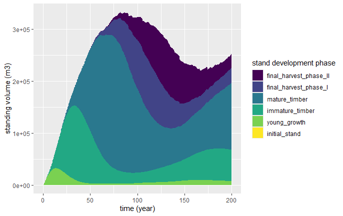

```r
plot(sim_base_out, variable = "vol_standing") # standing volume
```

Second, we plot the total harvested volume. The sharp peaks result from wood that is removed due to hazard events.

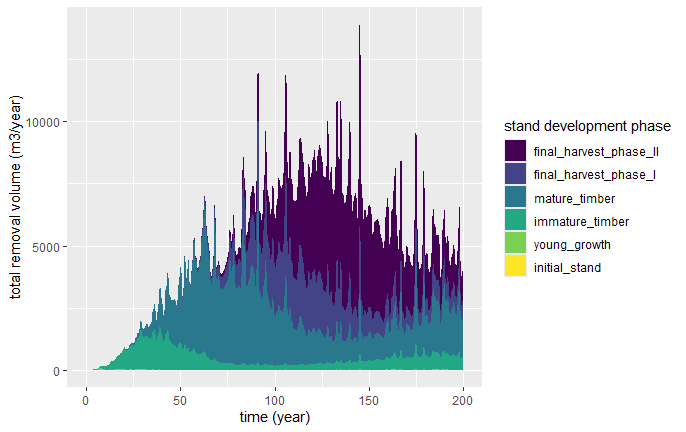

```r
plot(sim_base_out, variable = "vol_rmv_total") # total harvested volume
```

### 3.4 Calculating carbon related results

In order to obtain the fuel consumption, and subsequently the CO<sub>2</sub> emissions caused by forest operations, the package provides the function `fuel_and_co2_evaluation`. The forest operations taken into account comprise cutting, moving the timber to the forest road (forwarding, skidding), and maintenance of the forest road network. A typical call of `fuel_and_co2_evaluation` in the context of our example is shown below. Note that in contrast to the quickstart section, we explicitly call parameters with default values for demonstration.

```r
# Calculate information about fuel consumption
# call documentation with ?fuel_and_co2_evaluation for detail information
carbon_out <- fuel_and_co2_evaluation(
  sim_base_out,             # object obtained from simulate_single_concept
  road_density_m_ha = 35,   # forest road density
  raw_density_kg_m3 = 520,  # default setting, wood density
  harvest_loss      = 0.1,  # default, share of volume lost at harvest
  bark_share        = 0.12, # default, bark share of volume
  mode  = "standard" # default, choice is between "standard" and "nordic"
)
```

The only parameters, the user must provide in any case, are an object of class `c4c_base_result` as obtained from `simulate_single_concept()` and the forest road density (m/ha) in the area of interest (relating to truck roads). The parameter `mode` allows to choose the assumptions for the harvest operations. Currently, there are only two options, “standard”, and “nordic”. In both cases, it is assumed that the wood is felled and cut by a harvester, and transported to the forest road with a forwarder. With the option “standard”, the model uses functions estimated after Bacescu et al. (2022) and Grigolato and Cadei (2022). With the option “nordic”, we apply functions provided by Kärhä et al. (2023), instead. As the cutting under the option “standard” does only take into account harvest operations with stem diameters at breast height of at least 15 cm, it uses the cutting function by Kärhä et al. (2023) in case of smaller lots. The estimate for fuel consumption due to forest road maintenance is estimated after Enache and Stampfer (2015) with both options. For details about the other parameters call `?fuel_and_co2_evaluation`.

The output of the function `fuel_and_co2_evaluation()` is an object of class `c4c_co2_result`. It is, in essence, a named list containing the following elements:

```r
names(carbon_out)
```

```
#> [1] "concept"        "time_span"      "detailed_init"  "init_areas"
#> [5] "risk_level"     "parameters_co2" "co2_agg_high"   "co2_agg_medium"
#> [9] "co2_by_phases"
```

Similar as for the base simulation results described in Section 3.3, the first six list elements document the settings used for the calculations. The three remaining items, `co2_agg_high`, `co2_agg_medium`, `co2_by_phases` are all data frames that contain the actual outcomes, each on a different level of aggregation. We show them below, but note, that depending on your machine, some columns will be probably cut off and only mentioned under *more variables* underneath the data frame. The variable names should be self-explaining, note that for all operations we provide both, the fuel consumption and the CO<sub>2</sub> emissions.

```r
carbon_out$co2_agg_high
```

```
#> # A tibble: 201 × 10
#>     time fuel_cutting_total_l fuel_moving_total_l fuel_road_maint_total_l
#>    <dbl>                <dbl>               <dbl>                   <dbl>
#>  1     0                0                  0                         8750
#>  2     1                0.117              0.0174                    8750
#>  3     2                7.79               0.487                     8750
#>  4     3               40.4                2.42                      8750
#>  5     4               78.6                5.47                      8750
#>  6     5               75.3                7.98                      8750
#>  7     6              112.                13.6                       8750
#>  8     7              825.                55.0                       8750
#>  9     8              987.                73.5                       8750
#> 10     9              722.                69.0                       8750
#> # ℹ 191 more rows
#> # ℹ 6 more variables: co2_cutting_total_kg <dbl>, co2_moving_total_kg <dbl>,
#> #   co2_road_maint_total_kg <dbl>, co2_equiv_harvest_kg <dbl>,
#> #   co2_equiv_inc_kg <dbl>, co2_equiv_standing_kg <dbl>
```

```r
carbon_out$co2_agg_medium
```

```
#> # A tibble: 402 × 7
#> # Groups:   time [201]
#>     time harvest_type fuel_cutting_total_l fuel_moving_total_l
#>    <dbl> <chr>                       <dbl>               <dbl>
#>  1     0 damage                      0                  0
#>  2     0 regular                     0                  0
#>  3     1 damage                      0                  0
#>  4     1 regular                     0.117              0.0174
#>  5     2 damage                      6.14               0.241
#>  6     2 regular                     1.65               0.246
#>  7     3 damage                     33.0                1.32
#>  8     3 regular                     7.37               1.10
#>  9     4 damage                     58.0                2.40
#> 10     4 regular                    20.6                3.07
#> # ℹ 392 more rows
#> # ℹ 3 more variables: co2_cutting_total_kg <dbl>, co2_moving_total_kg <dbl>,
#> #   co2_equiv_harvest_kg <dbl>
```

```r
carbon_out$co2_by_phases
```

```
#> # A tibble: 2,412 × 11
#>     time harvest_type phase_no phase_name            fuel_cutting_l_per_m3
#>    <dbl> <chr>           <int> <chr>                                 <dbl>
#>  1     0 damage              1 initial_stand                         0
#>  2     0 regular             1 initial_stand                         0
#>  3     0 damage              2 young_growth                         11.3
#>  4     0 regular             2 young_growth                          0
#>  5     0 damage              3 immature_timber                       2.79
#>  6     0 regular             3 immature_timber                       2.97
#>  7     0 damage              4 mature_timber                         0.813
#>  8     0 regular             4 mature_timber                         0.674
#>  9     0 damage              5 final_harvest_phase_I                 0.571
#> 10     0 regular             5 final_harvest_phase_I                 0.531
#> # ℹ 2,402 more rows
#> # ℹ 6 more variables: fuel_cutting_total_l <dbl>, co2_cutting_total_kg <dbl>,
#> #   fuel_moving_l_per_m3 <dbl>, fuel_moving_total_l <dbl>,
#> #   co2_moving_total_kg <dbl>, co2_equiv_harvest_kg <dbl>
```

As a tool for facilitating visualization, we also provide a plot functions for the output objects of the function `fuel_and_co2_evaluation()`. Call `?plot.c4c_co2_result` for a full documentation. In the quickstart section, we have provided an example plot, where the CO<sub>2</sub> emissions were plotted against the wood increment in CO<sub>2</sub> equivalents. Due to the CRAN policies, we cannot show the full set of possible diagrams in this vignette; the user is encouraged to check the documentation and try out the available options. First, we show for our example the total CO<sub>2</sub> emissions split into the components “cutting”, “moving”, and “road maintenance:

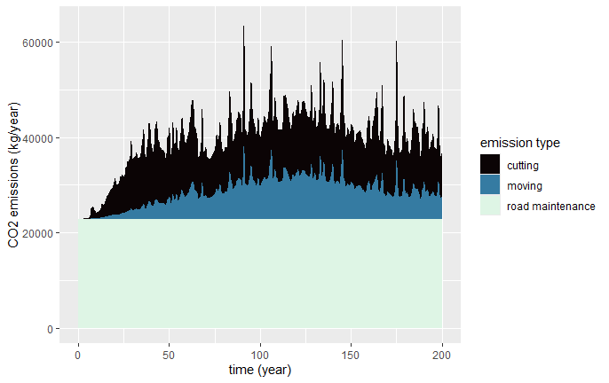

```r
plot(carbon_out, plot_type = "em_by_type")
```

Second, plotting the ratio of all CO<sub>2</sub> emissions and the wood increment (in CO<sub>2</sub> equivalents). Note that, in general, the emissions are between three and two magnitudes smaller compared to the increment.

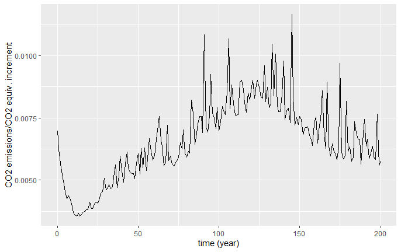

```r
plot(carbon_out, plot_type = "em_inc_ratio")
```

## 4 Further functions

When calling the documentation of any function contained in the package *care4cmodel*, e.g. with `?simulate_single_concept` and scrolling down to the bottom of the page, there is a link called “Index”. Following this link leads to a complete list of documented functions the package provides for users. Typically, most of these functions are internally used in the workflow described above. Advanced users, however, might find some useful tools among them.

## 5 Acknowledgment

This R package has been developed as a part of the [CARE4C](http://www.care4c.eu/) project that has received funding from the European Union’s HORIZON 2020 research and innovation programme under the Marie Skłodowska-Curie grant agreement # 778322.

## 6 References

Bacescu, Narcis Mihail, Alberto Cadei, Tadeusz Moskalik, Mateusz Wiśniewski, Bruce Talbot, and Stefano Grigolato. 2022. “Efficiency Assessment of Fully Mechanized Harvesting System Through the Use of Fleet Management System.” *Sustainability* 14 (24). https://doi.org/10.3390/su142416751.

Biber, Peter, Stefano Grigolato, Julia Schmucker, Hans Pretzsch, and Enno Uhl. 2024. “A Generic Simulation Model for Relating Forest CO2 Intake and CO2 Emissions by Forest Operations – the r-Package Care4cmodel.” *Computers and Electronics in Agriculture* 222: 109091. https://doi.org/https://doi.org/10.1016/j.compag.2024.109091.

Enache, A, and K Stampfer. 2015. “Machine Utilization Rates, Energy Requirements and Greenhouse Gas Emissions of Forest Road Construction and Maintenance in Romanian Mountain Forests.” *Journal of Green Engineering* 4 (4): 325–50.

Grigolato, Stefano, and Alberto Cadei. 2022. “Full-Mechanized CTL Production Data in Scots Pine Forest in Poland.” https://researchdata.cab.unipd.it/659/.

Kärhä, Kalle, Hanna Haavikko, Heikki Kääriäinen, Teijo Palander, Lars Eliasson, and Kimmo Roininen. 2023. “Fossil-Fuel Consumption and CO2eq Emissions of Cut-to-Length Industrial Roundwood Logging Operations in Finland.” *European Journal of Forest Research*, 1–17.

Karline Soetaert, Thomas Petzoldt, and R. Woodrow Setzer. 2010. “Solving Differential Equations in R: Package deSolve.” *Journal of Statistical Software* 33 (9): 1–25. https://doi.org/10.18637/jss.v033.i09.